# Project #4_Concrete Strength Prediction

### Problem Statement:Concrete Strength Prediction

Objective: To predict the concrete strength using the data available in file concrete_data.xls. Apply feature engineering and model tuning to obtain 80% to 95% of R2score

## Resources Available The data for this project is available in file https://archive.ics.uci.edu/ml/machine-learning-databases/concrete/compressive/.

The same has been shared along with the course content.Steps and Tasks:

Exploratory data quality report reflecting the following:

1.Univariate analysis –data types and description of the independent attributes which should include (name, range of values observed, central values (mean and median), standard deviation and quartiles, analysis of the body of distributions / tails, missing values, outliers, duplicates(10 Marks)

2.Bi-variate analysis between the predictor variables and between the predictor variables and target column. Comment on your findings in terms of their relationship and degree of relation if any. Visualize the analysis using boxplots and pair plots, histograms or density curves. (10 marks)

3.Feature Engineering techniques(10 marks)

a.Identify opportunities (if any) to extracta new featurefrom existing features, drop a feature(if required)

b.Get data model ready and do a train test split.

c.Decide on complexity of the model, should it be simple linear model in terms of parameters or would aquadratic or higher degree.

Creating the model and tuning it

1.Algorithms that you think will be suitable for this project.Use Kfold Cross Validation toevaluate model performance.Use appropriate metrics and make a DataFrame to compare models w.r.t their metrics.(at least 3 algorithms, one bagging and one boosting based algorithms has to be there).(15 marks)

2.Techniques employed to squeeze that extra performance out of the model without making it overfit.Use Grid Search orRandom Search on any of the two modelsused above. Make a DataFrame to compare models after hyperparameter tuning and their metrics as above. (15 marks)

Attribute Information:Given are the variable name, variable type, the measurement unit and a brief description. The concrete compressive strength is the regression problem. The order of this listing corresponds to the order of numerals along the rows of the database.

Name --Data Type --Measurement --Description

Cement (cement) --quantitative --kg in a m3 mixture --Input Variable

Blast Furnace Slag (slag) --quantitative --kg in a m3 mixture --Input Variable

Fly Ash (ash) --quantitative --kg in a m3 mixture --Input Variable

Water(water) --quantitative --kg in a m3 mixture --Input Variable

Superplasticizer (superplastic) --quantitative --kg in a m3 mixture --Input Variable

Coarse Aggregate (coarseagg) --quantitative --kg in a m3 mixture --Input Variable

Fine Aggregate (fineagg) --quantitative --kg in a m3 mixture --Input Variable

Age(age) --quantitative --Day (1~365) --Input Variable

Concrete compressive strength(strength) --quantitative --MPa --Output Variable

#### Import the necessary packages

```python
import numpy as np
import pandas as pd
import matplotlib.pyplot as plt
%matplotlib inline
import seaborn as sns
```

```python
sns.set(color_codes=True) # adds a nice background to the graphs
import warnings
warnings.filterwarnings('ignore')
```

### Univariate analysis (12 marks)

```python
con_df = pd.read_csv('concrete.csv')
con_df.head(10)
```

|  | cement | slag | ash | water | superplastic | coarseagg | fineagg | age | strength |
| --- | --- | --- | --- | --- | --- | --- | --- | --- | --- |
| 0 | 141.3 | 212.0 | 0.0 | 203.5 | 0.0 | 971.8 | 748.5 | 28 | 29.89 |
| 1 | 168.9 | 42.2 | 124.3 | 158.3 | 10.8 | 1080.8 | 796.2 | 14 | 23.51 |
| 2 | 250.0 | 0.0 | 95.7 | 187.4 | 5.5 | 956.9 | 861.2 | 28 | 29.22 |
| 3 | 266.0 | 114.0 | 0.0 | 228.0 | 0.0 | 932.0 | 670.0 | 28 | 45.85 |
| 4 | 154.8 | 183.4 | 0.0 | 193.3 | 9.1 | 1047.4 | 696.7 | 28 | 18.29 |
| 5 | 255.0 | 0.0 | 0.0 | 192.0 | 0.0 | 889.8 | 945.0 | 90 | 21.86 |
| 6 | 166.8 | 250.2 | 0.0 | 203.5 | 0.0 | 975.6 | 692.6 | 7 | 15.75 |
| 7 | 251.4 | 0.0 | 118.3 | 188.5 | 6.4 | 1028.4 | 757.7 | 56 | 36.64 |
| 8 | 296.0 | 0.0 | 0.0 | 192.0 | 0.0 | 1085.0 | 765.0 | 28 | 21.65 |
| 9 | 155.0 | 184.0 | 143.0 | 194.0 | 9.0 | 880.0 | 699.0 | 28 | 28.99 |

```python
con_df.shape
# get the number of rows and columns of the dataset
```

```
(1030, 9)
```

```python
#bankdata.isnull().sum() #check for null Values
con_df.isnull().values.any() #Check if there is any null entry in the data; the answer is no
```

```
False
```

```python
con_df.describe().transpose()
#get descriptive statistics of the numerical variables
```

|  | count | mean | std | min | 25% | 50% | 75% | max |
| --- | --- | --- | --- | --- | --- | --- | --- | --- |
| cement | 1030.0 | 281.167864 | 104.506364 | 102.00 | 192.375 | 272.900 | 350.000 | 540.0 |
| slag | 1030.0 | 73.895825 | 86.279342 | 0.00 | 0.000 | 22.000 | 142.950 | 359.4 |
| ash | 1030.0 | 54.188350 | 63.997004 | 0.00 | 0.000 | 0.000 | 118.300 | 200.1 |
| water | 1030.0 | 181.567282 | 21.354219 | 121.80 | 164.900 | 185.000 | 192.000 | 247.0 |
| superplastic | 1030.0 | 6.204660 | 5.973841 | 0.00 | 0.000 | 6.400 | 10.200 | 32.2 |
| coarseagg | 1030.0 | 972.918932 | 77.753954 | 801.00 | 932.000 | 968.000 | 1029.400 | 1145.0 |
| fineagg | 1030.0 | 773.580485 | 80.175980 | 594.00 | 730.950 | 779.500 | 824.000 | 992.6 |
| age | 1030.0 | 45.662136 | 63.169912 | 1.00 | 7.000 | 28.000 | 56.000 | 365.0 |
| strength | 1030.0 | 35.817961 | 16.705742 | 2.33 | 23.710 | 34.445 | 46.135 | 82.6 |

```python
zero_percent = con_df[con_df == 0].count(axis=0)*100/con_df.shape[0]
zero_df = pd.DataFrame(zero_percent,columns=['Percent of zero values'])
zero_df.index.name = 'Feature Name'
zero_df
#count the percentage of zeros in each column
```

| Feature Name | Percent of zero values |
| --- | --- |
| cement | 0.000000 |
| slag | 45.728155 |
| ash | 54.951456 |
| water | 0.000000 |
| superplastic | 36.796117 |
| coarseagg | 0.000000 |
| fineagg | 0.000000 |
| age | 0.000000 |
| strength | 0.000000 |

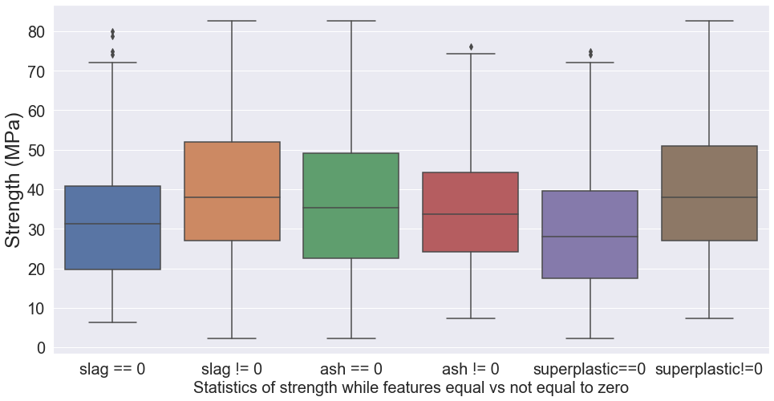

```python
con_df['slag == 0'] = np.where(con_df.slag == 0, con_df.strength, 'nan')
con_df['slag != 0'] = np.where(con_df.slag != 0, con_df.strength, 'nan')
con_df['ash == 0'] = np.where(con_df.ash == 0, con_df.strength, 'nan')
con_df['ash != 0'] = np.where(con_df.ash != 0, con_df.strength, 'nan')
con_df['superplastic==0'] = np.where(con_df.superplastic == 0, con_df.strength, 'nan')
con_df['superplastic!=0'] = np.where(con_df.superplastic != 0, con_df.strength, 'nan')

plt.figure(figsize=(16,8))
ax=sns.boxplot(data = con_df.iloc[:,9:15])
ax.set_xlabel("Statistics of strength while features equal vs not equal to zero",fontsize=20)
ax.set_ylabel("Strength (MPa)",fontsize=25)
ax.tick_params('both', labelsize='20')
plt.show()
#Get a visual look of statistics of "strength" by distingusihing if three features' values
#are zero or not, the three features are "slag", "ash","superplastic"; "Ash" has the
#most zero values
```

From the above analysis,strenths are significantly different when features (slag and suplerplastic) are equal to vs not equal to zero; therefore, zeros in these data points are most probably effective values; The range of strength is narrower while ash is not equal to zero compared to while equals zero, making it seems like ash is stablizing strength values

```python
con_df.drop(con_df.iloc[:, 9:15], inplace = True, axis = 1)
con_df.head(10)
#remove extra columns added for the above plot
```

| Feature Name | cement | slag | ash | water | superplastic | coarseagg | fineagg | age | strength |
| --- | --- | --- | --- | --- | --- | --- | --- | --- | --- |
| 0 | 141.3 | 212.0 | 0.0 | 203.5 | 0.0 | 971.8 | 748.5 | 28 | 29.89 |
| 1 | 168.9 | 42.2 | 124.3 | 158.3 | 10.8 | 1080.8 | 796.2 | 14 | 23.51 |
| 2 | 250.0 | 0.0 | 95.7 | 187.4 | 5.5 | 956.9 | 861.2 | 28 | 29.22 |
| 3 | 266.0 | 114.0 | 0.0 | 228.0 | 0.0 | 932.0 | 670.0 | 28 | 45.85 |
| 4 | 154.8 | 183.4 | 0.0 | 193.3 | 9.1 | 1047.4 | 696.7 | 28 | 18.29 |
| 5 | 255.0 | 0.0 | 0.0 | 192.0 | 0.0 | 889.8 | 945.0 | 90 | 21.86 |
| 6 | 166.8 | 250.2 | 0.0 | 203.5 | 0.0 | 975.6 | 692.6 | 7 | 15.75 |
| 7 | 251.4 | 0.0 | 118.3 | 188.5 | 6.4 | 1028.4 | 757.7 | 56 | 36.64 |
| 8 | 296.0 | 0.0 | 0.0 | 192.0 | 0.0 | 1085.0 | 765.0 | 28 | 21.65 |
| 9 | 155.0 | 184.0 | 143.0 | 194.0 | 9.0 | 880.0 | 699.0 | 28 | 28.99 |

```python
con_df.skew()
```

```
Feature Name
cement          0.509481
slag            0.800717
ash             0.537354
water           0.074628
superplastic    0.907203
coarseagg      -0.040220
fineagg        -0.253010
age             3.269177
strength        0.416977
dtype: float64
```

# Only age value is highly skewed

```python
unique = pd.DataFrame(con_df.nunique())
unique.columns = ['cnt_unique_values']
unique.T
#Table list the number of unique values of each parameter
```

| Feature Name | cement | slag | ash | water | superplastic | coarseagg | fineagg | age | strength |
| --- | --- | --- | --- | --- | --- | --- | --- | --- | --- |
| cnt_unique_values | 278 | 185 | 156 | 195 | 111 | 284 | 302 | 14 | 845 |

```python
con_df.info()
```

```
<class 'pandas.core.frame.DataFrame'>
RangeIndex: 1030 entries, 0 to 1029
Data columns (total 9 columns):
 #   Column        Non-Null Count  Dtype
---  ------        --------------  -----
 0   cement        1030 non-null   float64
 1   slag          1030 non-null   float64
 2   ash           1030 non-null   float64
 3   water         1030 non-null   float64
 4   superplastic  1030 non-null   float64
 5   coarseagg     1030 non-null   float64
 6   fineagg       1030 non-null   float64
 7   age           1030 non-null   int64
 8   strength      1030 non-null   float64
dtypes: float64(8), int64(1)
memory usage: 72.5 KB
```

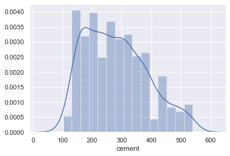

```python
sns.distplot(con_df['cement']);
```

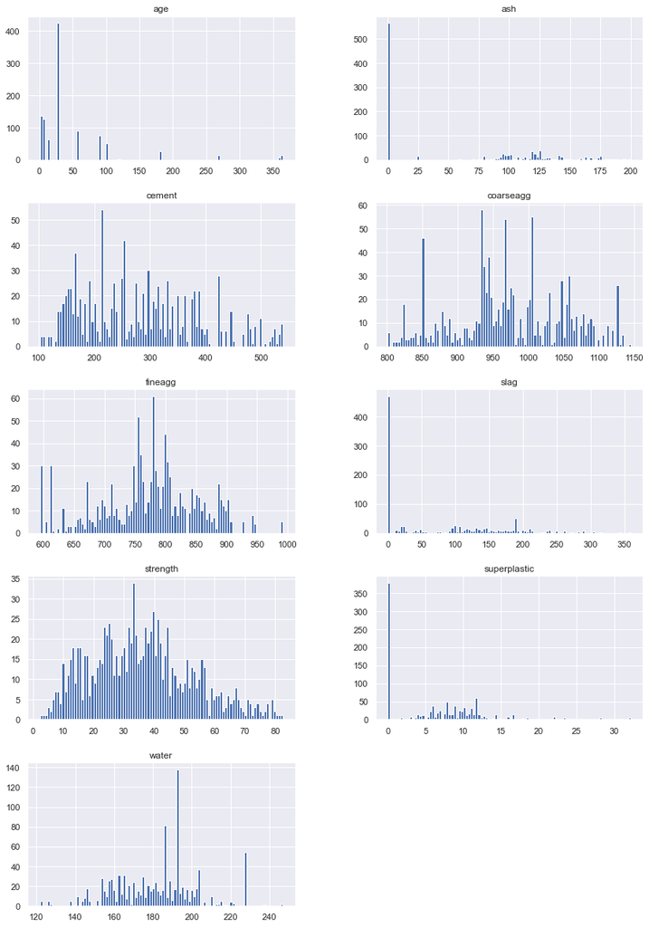

```python
columns = list(con_df)[:] # get all the colomn names
con_df[columns].hist(stacked=False, bins=100, figsize=(14,60), layout=(14,2));
#plot histograms of each column with numerical values
```

```python
con_df['age'].unique()
```

```
array([ 28,  14,  90,   7,  56,   3, 100,  91, 180, 365, 270, 360, 120,
         1])
```

```python
con_df['age'].value_counts()
```

```
28     425
3      134
7      126
56      91
14      62
90      54
100     52
180     26
91      22
365     14
270     13
360      6
120      3
1        2
Name: age, dtype: int64
```

```python
con_age=con_df.groupby(['age']).mean()
```

```python
con_age
```

| Feature Name age | cement | slag | ash | water | superplastic | coarseagg | fineagg | strength |
| --- | --- | --- | --- | --- | --- | --- | --- | --- |
| 1 | 442.500000 | 0.000000 | 0.000000 | 193.000000 | 0.000000 | 1045.500000 | 688.000000 | 9.455000 |
| 3 | 286.581343 | 65.977612 | 57.164179 | 176.188806 | 6.616418 | 977.247761 | 796.111940 | 18.981194 |
| 7 | 312.923810 | 92.943651 | 12.642857 | 183.287302 | 3.750000 | 983.814286 | 768.103175 | 26.050873 |
| 14 | 246.182258 | 18.590323 | 97.854839 | 173.390323 | 6.679032 | 1023.909677 | 800.119355 | 28.750968 |
| 28 | 265.444471 | 86.285176 | 62.795294 | 183.059529 | 6.995765 | 956.059294 | 764.377412 | 36.748612 |
| 56 | 294.173626 | 55.221978 | 85.043956 | 167.448352 | 9.856044 | 979.635165 | 798.491209 | 51.890220 |
| 90 | 284.140741 | 88.524074 | 0.000000 | 200.768519 | 0.000000 | 966.137037 | 758.662963 | 40.480370 |
| 91 | 392.263636 | 148.809091 | 0.000000 | 157.763636 | 15.154545 | 918.940909 | 802.336364 | 69.808636 |
| 100 | 220.909615 | 22.165385 | 116.673077 | 169.446154 | 7.963462 | 1025.296154 | 809.450000 | 47.668846 |
| 120 | 330.000000 | 0.000000 | 0.000000 | 192.000000 | 0.000000 | 1031.000000 | 820.000000 | 39.646667 |
| 180 | 331.334615 | 49.319231 | 0.000000 | 207.038462 | 0.000000 | 979.900000 | 725.438462 | 41.730385 |
| 270 | 376.884615 | 72.346154 | 0.000000 | 218.615385 | 0.000000 | 976.538462 | 627.615385 | 51.272308 |
| 360 | 267.533333 | 56.966667 | 0.000000 | 191.833333 | 0.000000 | 998.066667 | 828.233333 | 40.696667 |
| 365 | 319.321429 | 67.178571 | 0.000000 | 218.642857 | 0.000000 | 942.285714 | 690.071429 | 43.557857 |

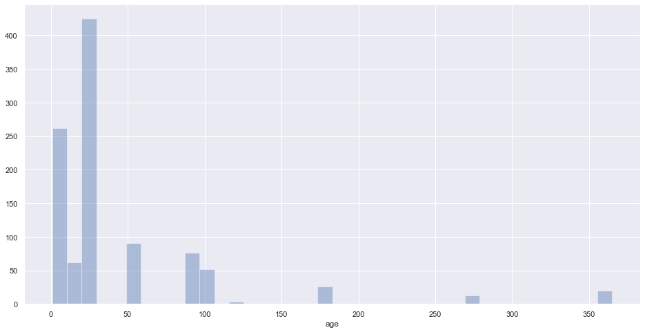

```python
plt.figure(figsize=(16,8))
sns.distplot(con_df['age'],kde=0);
```

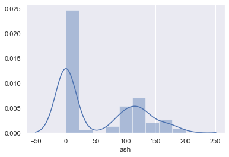

```python
sns.distplot(con_df['ash'],kde = 1);
```

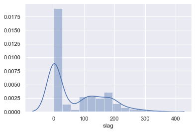

```python
sns.distplot(con_df['slag'],kde=1);
```

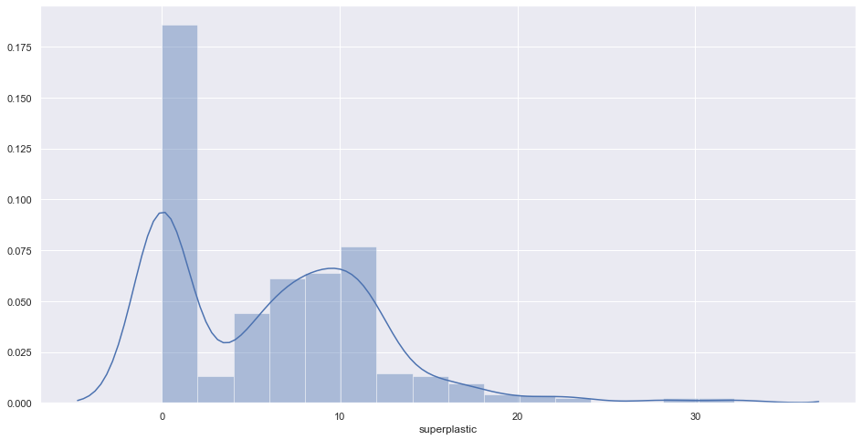

```python
plt.figure(figsize=(16,8))
sns.distplot(con_df['superplastic'],kde=1);
```

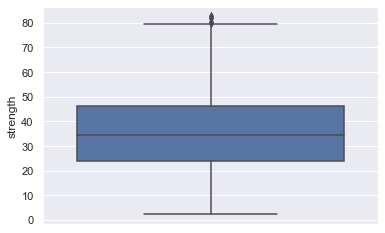

```python
sns.boxplot(con_df['strength'],orient='v')
plt.show()
```

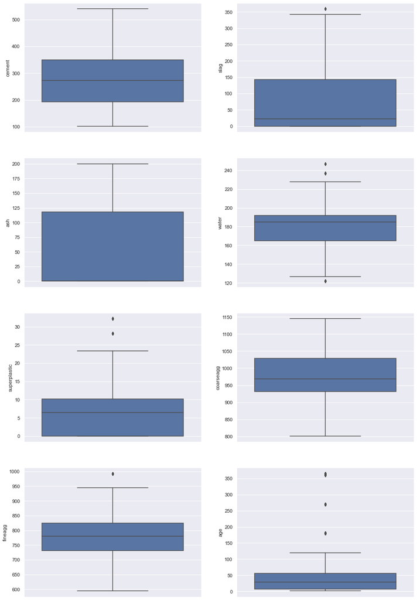

```python
fig, ax =plt.subplots(4,2,figsize=(16,25))
sns.boxplot(con_df['cement'],orient = 'v', ax=ax[0,0])
sns.boxplot(con_df['slag'],orient = 'v', ax=ax[0,1])
sns.boxplot(con_df['ash'],orient = 'v', ax=ax[1,0]);
sns.boxplot(con_df['water'],orient = 'v', ax=ax[1,1]);
sns.boxplot(con_df['superplastic'],orient = 'v', ax=ax[2,0]);
sns.boxplot(con_df['coarseagg'],orient = 'v', ax=ax[2,1]);
sns.boxplot(con_df['fineagg'],orient = 'v', ax=ax[3,0]);
sns.boxplot(con_df['age'],orient = 'v', ax=ax[3,1]);
plt.rcParams["axes.labelsize"] = 40
fig.show()
```

### Multivariate analysis (8 marks)

```python
con_df.corr()
# It will show correlation matrix
#"strength" has strong correlation with "cement", following with "superplastic" and "age"
#intestingly, "ash" and "superplastic" are positively correlated; similarly "age" vs "water"
```

| Feature Name | cement | slag | ash | water | superplastic | coarseagg | fineagg | age | strength |
| --- | --- | --- | --- | --- | --- | --- | --- | --- | --- |
| cement | 1.000000 | -0.275216 | -0.397467 | -0.081587 | 0.092386 | -0.109349 | -0.222718 | 0.081946 | 0.497832 |
| slag | -0.275216 | 1.000000 | -0.323580 | 0.107252 | 0.043270 | -0.283999 | -0.281603 | -0.044246 | 0.134829 |
| ash | -0.397467 | -0.323580 | 1.000000 | -0.256984 | 0.377503 | -0.009961 | 0.079108 | -0.154371 | -0.105755 |
| water | -0.081587 | 0.107252 | -0.256984 | 1.000000 | -0.657533 | -0.182294 | -0.450661 | 0.277618 | -0.289633 |
| superplastic | 0.092386 | 0.043270 | 0.377503 | -0.657533 | 1.000000 | -0.265999 | 0.222691 | -0.192700 | 0.366079 |
| coarseagg | -0.109349 | -0.283999 | -0.009961 | -0.182294 | -0.265999 | 1.000000 | -0.178481 | -0.003016 | -0.164935 |
| fineagg | -0.222718 | -0.281603 | 0.079108 | -0.450661 | 0.222691 | -0.178481 | 1.000000 | -0.156095 | -0.167241 |
| age | 0.081946 | -0.044246 | -0.154371 | 0.277618 | -0.192700 | -0.003016 | -0.156095 | 1.000000 | 0.328873 |
| strength | 0.497832 | 0.134829 | -0.105755 | -0.289633 | 0.366079 | -0.164935 | -0.167241 | 0.328873 | 1.000000 |

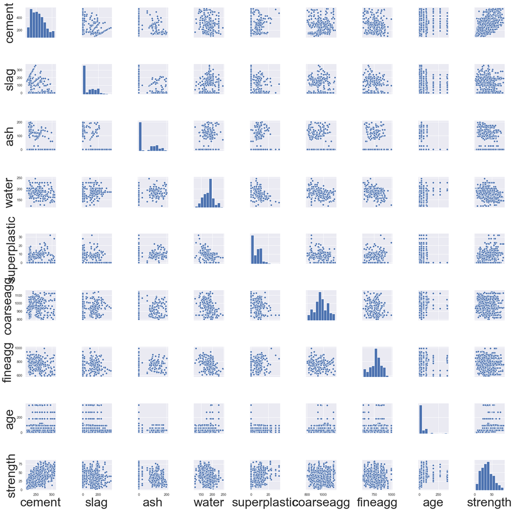

```python
sns.pairplot(con_df);
```

#### 3. Feature Engineering techniques (10 marks)

a. Identify opportunities (if any) to extract a new feature from existing features, drop a feature (if required)

b. Get data model ready and do a train test split.

c. Decide on complexity of the model, should it be simple linear model in terms of parameters or would a quadratic or higher degree.

## separate independent and dependent variables

```python
X = con_df.drop('strength',axis=1)     #Dependent variable is "strength"
y = con_df[['strength']]   # Independent variable
```

## Build a linear model first

```python
# Import Linear Regression machine learning library
from sklearn.linear_model import LinearRegression
from sklearn.linear_model import Ridge
from sklearn.linear_model import Lasso

from sklearn.metrics import r2_score
from sklearn import preprocessing
```

```python
from sklearn import preprocessing

# scale all the columns of the con_df. This will produce a numpy array
X_scaled = preprocessing.scale(X)
X_scaled = pd.DataFrame(X_scaled, columns=X.columns)  # ideally the training and test should be

y_scaled = preprocessing.scale(y)
y_scaled = pd.DataFrame(y_scaled, columns=y.columns)  # ideally the training and test should be
```

```python
from sklearn.model_selection import train_test_split

X_train, X_test, y_train, y_test = train_test_split(X_scaled, y_scaled, test_size=0.30, random_state=1)
```

```python
print("{0:0.2f}% data is in training set".format((len(X_train)/len(con_df.index)) * 100))
print("{0:0.2f}% data is in test set".format((len(X_test)/len(con_df.index)) * 100))
```

```
70.00% data is in training set
30.00% data is in test set
```

```python
y_test.mean()/y_train.mean()#Check the average value of Y variable for test and train sets
```

```
Feature Name
strength   -2.333333
dtype: float64
```

## fit a simple linear model

```python
lm = LinearRegression()
lm.fit(X_train, y_train)
```

```
LinearRegression(copy_X=True, fit_intercept=True, n_jobs=None, normalize=False)
```

```python
lm.coef_
```

```
array([[ 0.79170803,  0.56206087,  0.34747677, -0.13186138,  0.13449877,
         0.11183689,  0.1737008 ,  0.41759098]])
```

```python
lm.coef_.shape
```

```
(1, 8)
```

```python
#Here are the coefficients for each variable and the intercept
for idx, col_name in enumerate(X_train.columns):
    print("The coefficient for {} is {}".format(col_name, lm.coef_[0,[idx]]))
```

```
The coefficient for cement is [0.79170803]
The coefficient for slag is [0.56206087]
The coefficient for ash is [0.34747677]
The coefficient for water is [-0.13186138]
The coefficient for superplastic is [0.13449877]
The coefficient for coarseagg is [0.11183689]
The coefficient for fineagg is [0.1737008]
The coefficient for age is [0.41759098]
```

```python
intercept = lm.intercept_
print("The intercept for our model is {}".format(intercept))
```

```
The intercept for our model is [-0.0130414]
```

```python
r_squared=lm.score(X_train, y_train)
print("The R squared value for linear regression model is",r_squared)
#Linear model's performance is too poor, therefore no more study will be pursued
```

```
The R squared value for linear regression model is 0.6031487540630229
```

## Create a regularized RIDGE model and note the coefficients¶

```python
ridge = Ridge(alpha=.3)
ridge.fit(X_train,y_train)
print ("Ridge model:", (ridge.coef_))
```

```
Ridge model: [[ 0.78652136  0.55696657  0.34291358 -0.13534196  0.13450497  0.10831507
   0.16918324  0.41713594]]
```

## Create a regularized LASSO model and note the coefficients

```python
lasso = Lasso(alpha=0.1)
lasso.fit(X_train,y_train)
print ("Lasso model:", (lasso.coef_))

# Observe, many of the coefficients have become 0 indicating drop of those dimensions from the model
```

```
Lasso model: [ 0.39456594  0.14777481  0.         -0.11823668  0.19361099 -0.
 -0.          0.2543608 ]
```

```python
lasso.coef_.shape
```

```
(8,)
```

```python
for idx, col_name in enumerate(X_train.columns):
    print("The coefficient for {} is {}".format(col_name, lasso.coef_[idx]))
#Here are the coefficients for each variable and the intercept based on lasso model
```

```
The coefficient for cement is 0.39456594309288484
The coefficient for slag is 0.14777480587625938
The coefficient for ash is 0.0
The coefficient for water is -0.1182366796885254
The coefficient for superplastic is 0.19361099150006766
The coefficient for coarseagg is -0.0
The coefficient for fineagg is -0.0
The coefficient for age is 0.2543607989845128
```

## Let us compare their scores

```python
print(lm.score(X_train, y_train))
print(lm.score(X_test, y_test))
```

```
0.6031487540630229
0.6339136715208274
```

```python
print(ridge.score(X_train, y_train))
print(ridge.score(X_test, y_test))
```

```
0.603144790939098
0.6340333563625515
```

```python
print(lasso.score(X_train, y_train))
print(lasso.score(X_test, y_test))
```

```
0.5215627623725143
0.5185661488869902
```

Lasso has lower score but with three features not involved in prediction. "ash", "coarseagg", "fineagg" these three columns are still contributing to the score significantly and shouldn't be discarded for the model building

## Let us generate polynomial models reflecting the non-linear interaction between some dimensions

```python
from sklearn.preprocessing import PolynomialFeatures

poly = PolynomialFeatures(degree = 2, interaction_only=True)

X_poly = poly.fit_transform(X_scaled)
X_train, X_test, y_train, y_test = train_test_split(X_poly, y, test_size=0.30, random_state=1)
X_train.shape
```

```
(721, 37)
```

## Fit a simple non regularized linear model and RIDGE & LASSO regularized models on poly features

```python
lm.fit(X_train, y_train)
print(lm.coef_[0])
```

```
[ 5.02512283e-17  1.34777181e+01  1.01453909e+01  6.05814040e+00
 -1.56595255e+00  4.25130927e+00  1.23634849e+00  2.53761032e+00
  1.49772131e+01  7.59594704e-01  1.15681909e+00 -3.90120685e+00
 -1.73806869e+00  3.29193411e-01  6.17368282e-01  2.91053268e+00
  1.76307429e+00 -1.63204600e+00  5.21667573e-01  3.68167194e-01
  2.08128646e+00  4.26397239e+00 -2.31745785e+00 -2.32994460e+00
  2.58685837e-01  1.97858614e+00  6.75668908e+00  1.96653055e+00
 -1.09589014e+00 -3.09952083e-01 -9.61638886e-01  1.77590106e+00
  9.90577456e-01  2.40653442e+00  1.63052044e+00 -3.01539427e-01
  1.84973490e+00]
```

```python
print(lm.score(X_train, y_train))
print(lm.score(X_test, y_test))
```

```
0.754957826884826
0.7444710081439017
```

```python
ridge = Ridge(alpha=.3)
ridge.fit(X_train,y_train)
print ("Ridge model:", (ridge.coef_))
```

```
Ridge model: [[ 0.         13.3230364   9.98806788  5.92007287 -1.6769773   4.24346992
   1.14709561  2.40295661 14.94433259  0.75048865  1.15780428 -3.8556977
  -1.72087746  0.33506201  0.61718292  2.7638557   1.74523077 -1.60892884
   0.5291864   0.35781419  2.0722416   4.15030544 -2.26730837 -2.32755965
   0.26752031  1.98410524  6.6046349   1.97079137 -1.07823346 -0.3095362
  -1.03929564  1.77010082  0.98752549  2.43497624  1.63032432 -0.31792245
   1.73711233]]
```

```python
print(ridge.score(X_train, y_train))
print(ridge.score(X_test, y_test))
```

```
0.7549463250929687
0.7444379607063951
```

```python
lasso = Lasso(alpha=0.1)
lasso.fit(X_train,y_train)
print ("Lasso model:", (lasso.coef_))
```

```
Lasso model: [ 0.         10.38313413  6.71312204  2.90652138 -3.50322958  4.12879395
 -0.32930571  0.06610979 14.02555421  0.17923259  0.36709735 -1.76710531
 -1.08871369  0.0347827   0.37560336  0.          0.55217495 -0.
  0.88663059  0.          1.71890796  1.95781634 -0.28994533 -1.90371728
  0.          1.57752701  3.75047916  1.56988075 -0.57750007 -0.
 -1.48067583  1.63519198  0.59397392  3.46275015  1.39309712 -0.
 -0.        ]
```

```python
print(lasso.score(X_train, y_train))
print(lasso.score(X_test, y_test))
```

```
0.74559141484304
0.7330652318093241
```

```python
# Polymonial models seem to perform better than linear models
```

### Creating the model and tuning it

1. Algorithms that you think will be suitable for this project. Use K-fold Cross Validation to evaluate model performance. Use appropriate metrics and make a DataFrame to compare models w.r.t their metrics. (at least 3 algorithms, one bagging and one boosting based algorithms has to be there). (15 marks)

```python
from sklearn.model_selection import train_test_split
from sklearn.model_selection import KFold
from sklearn.model_selection import cross_val_score
from sklearn.preprocessing import StandardScaler

#scaler = StandardScaler()
#cols_to_scale = ['cement', 'slag', 'water', 'superplastic', 'coarseagg',
#       'fineagg', 'age', 'strength']
#con_df[cols_to_scale] = scaler.fit_transform(con_df[cols_to_scale].to_numpy())

model = LinearRegression()
array = con_df.values

X = array[:,0:8]
Y = array[:,8]

num_folds = 5
seed = 7

kfold = KFold(n_splits=num_folds, random_state=seed)


results = cross_val_score(model, X, Y, cv= kfold, scoring='r2')
print(results)
print("Accuracy: %.3f%% (%.3f%%)" % (results.mean()*100.0, results.std()*100.0))
```

```
[0.60623239 0.64695454 0.61555076 0.61208575 0.52561826]
Accuracy: 60.129% (4.039%)
```

```python
from sklearn.preprocessing import PolynomialFeatures

poly = PolynomialFeatures(degree = 2, interaction_only=True)

X_poly = poly.fit_transform(X)
results = cross_val_score(model, X_poly, Y, cv= kfold, scoring='r2')
print(results)
print("Accuracy: %.3f%% (%.3f%%)" % (results.mean()*100.0, results.std()*100.0))
```

```
[0.68646583 0.75101822 0.72735475 0.75376268 0.70381565]
Accuracy: 72.448% (2.624%)
```

```python
ridge = Ridge(alpha=.3)
results = cross_val_score(ridge, X_poly, Y, cv= kfold, scoring='r2')
print(results)
print("Accuracy: %.3f%% (%.3f%%)" % (results.mean()*100.0, results.std()*100.0))
```

```
[0.68647027 0.75104848 0.72740033 0.75379936 0.70402615]
Accuracy: 72.455% (2.622%)
```

```python
for alpha_value in [0.001, 0.005, 0.1, 0.5, 1.0, 5.0, 10]:
    lasso = Lasso(alpha=alpha_value)
    results = cross_val_score(lasso, X_poly, Y, cv= kfold, scoring='r2')
    print("For alpha =",alpha_value, results)
    print("Accuracy: %.3f%% (%.3f%%)" % (results.mean()*100.0, results.std()*100.0))
```

```
For alpha = 0.001 [0.68393459 0.75625681 0.73229883 0.75687163 0.70396169]
Accuracy: 72.666% (2.885%)
For alpha = 0.005 [0.68402393 0.7561921  0.7323344  0.75687246 0.7039936 ]
Accuracy: 72.668% (2.881%)
For alpha = 0.1 [0.68582456 0.75430615 0.73284298 0.7566093  0.70439939]
Accuracy: 72.680% (2.779%)
For alpha = 0.5 [0.68282463 0.75554682 0.7312348  0.75512585 0.70523142]
Accuracy: 72.599% (2.844%)
For alpha = 1.0 [0.67526281 0.75602628 0.72925039 0.75157483 0.70444553]
Accuracy: 72.331% (3.023%)
For alpha = 5.0 [0.66164113 0.74880064 0.72385581 0.73839514 0.69632783]
Accuracy: 71.380% (3.149%)
For alpha = 10 [0.66215184 0.7488068  0.72347729 0.73900558 0.69598659]
Accuracy: 71.389% (3.143%)
```

Overall, model geneated through k-fold CV has a score lower than a 0.7:0.3 Train--test split; However, K-fold cross validation has its merit and will be chosen as the base model here to compare the model score, based on the lasso model using the polynomial varialbes

```python
lasso = Lasso(alpha=0.1)
score1 = cross_val_score(lasso, X_poly, Y, cv= kfold, scoring='r2').mean()
score1
```

```
0.7267964778937117
```

## The following is to building models based on bagging and boosting algorithms

```python
from sklearn.ensemble import RandomForestRegressor
from sklearn.metrics import r2_score,mean_squared_error
for n_x in [5,10,20,50,100,200,500]:
    regr = RandomForestRegressor(n_estimators=n_x, max_depth=2, random_state=0)
    regr.fit(X_train, y_train)
    y_pred=regr.predict(X_test)
    mse=mean_squared_error(y_test, y_pred)
    rmse=np.sqrt(mse)
    print('RMSE for n_estimators equals',n_x,'is: ',rmse)
    print('Model score for n_estimators', n_x, 'is:', regr.score(X_test,y_test))
```

```
RMSE for n_estimators equals 5 is:  12.04337993334243
Model score for n_estimators 5 is: 0.5016381940844138
RMSE for n_estimators equals 10 is:  12.06989349175414
Model score for n_estimators 10 is: 0.49944148692323426
RMSE for n_estimators equals 20 is:  11.869334176793965
Model score for n_estimators 20 is: 0.5159383340126353
RMSE for n_estimators equals 50 is:  11.629260800685273
Model score for n_estimators 50 is: 0.5353219087037597
RMSE for n_estimators equals 100 is:  11.789116141805408
Model score for n_estimators 100 is: 0.5224592152355101
RMSE for n_estimators equals 200 is:  11.75543227629597
Model score for n_estimators 200 is: 0.5251841760796847
RMSE for n_estimators equals 500 is:  11.755550849262644
Model score for n_estimators 500 is: 0.5251745974264319
```

```python
for n_y in [1,2,3,4,5,6,7,8]:
    regr = RandomForestRegressor(max_depth=n_y, random_state=0)
    regr.fit(X_train, y_train)
    y_pred=regr.predict(X_test)
    mse=mean_squared_error(y_test, y_pred)
    rmse=np.sqrt(mse)
    print('RMSE for max_depth equals',n_y,'is: ',rmse)
    print('Model score for max_depth', n_y, 'is:', regr.score(X_test,y_test))
```

```
RMSE for max_depth equals 1 is:  14.398181834008046
Model score for max_depth 1 is: 0.2876994425308602
RMSE for max_depth equals 2 is:  11.789116141805408
Model score for max_depth 2 is: 0.5224592152355101
RMSE for max_depth equals 3 is:  9.955888269821772
Model score for max_depth 3 is: 0.6594287334000654
RMSE for max_depth equals 4 is:  8.4888736385072
Model score for max_depth 4 is: 0.7524014402138665
RMSE for max_depth equals 5 is:  7.537343792606684
Model score for max_depth 5 is: 0.804797836960434
RMSE for max_depth equals 6 is:  6.856821144265049
Model score for max_depth 6 is: 0.8384549634245467
RMSE for max_depth equals 7 is:  6.4456546340250975
Model score for max_depth 7 is: 0.8572480531406032
RMSE for max_depth equals 8 is:  6.208438744763822
Model score for max_depth 8 is: 0.8675619500689186
```

```python
regr = RandomForestRegressor(n_estimators=100,max_depth=3, random_state=0)
```

```python
results = cross_val_score(regr, X, Y, cv= kfold, scoring='r2')
print(results)
print("Accuracy: %.3f%% (%.3f%%)" % (results.mean()*100.0, results.std()*100.0))
```

```
[0.68814013 0.65563    0.7217758  0.70274048 0.61614197]
Accuracy: 67.689% (3.729%)
```

```python
results = cross_val_score(regr, X_poly, Y, cv= kfold, scoring='r2')
print(results)
print("Accuracy: %.3f%% (%.3f%%)" % (results.mean()*100.0, results.std()*100.0))
```

```
[0.74276659 0.75633325 0.7825742  0.75293309 0.74833469]
Accuracy: 75.659% (1.377%)
```

```python
from sklearn.ensemble import GradientBoostingRegressor
for n_x in [5,10,20,50,100,200,500]:
    boost = GradientBoostingRegressor(n_estimators=n_x,learning_rate=0.01, random_state=0)
    boost.fit(X_train, y_train)
    yb_pred=boost.predict(X_test)
    mse=mean_squared_error(y_test, yb_pred)
    rmse=np.sqrt(mse)
    print('RMSE for n_estimators equals',n_x,'is: ',rmse)
    print('Model score for n_estimators', n_x, 'is:', boost.score(X_test,y_test))
```

```
RMSE for n_estimators equals 5 is:  16.579180283125122
Model score for n_estimators 5 is: 0.055560626192360685
RMSE for n_estimators equals 10 is:  16.124847975707688
Model score for n_estimators 10 is: 0.10661381178491447
RMSE for n_estimators equals 20 is:  15.304101614473751
Model score for n_estimators 20 is: 0.19524504838276335
RMSE for n_estimators equals 50 is:  13.30290703436695
Model score for n_estimators 50 is: 0.3919474858684356
RMSE for n_estimators equals 100 is:  11.036190597297791
Model score for n_estimators 100 is: 0.5815087704362532
RMSE for n_estimators equals 200 is:  8.59848489205765
Model score for n_estimators 200 is: 0.7459660030698525
RMSE for n_estimators equals 500 is:  6.252021557746714
Model score for n_estimators 500 is: 0.865696011593404
```

```python
for n_y in [1,0.5,0.1,0.05,0.01,0.005,0.001]:
    boost = GradientBoostingRegressor(n_estimators=200,learning_rate=n_y, random_state=0)
    boost.fit(X_train, y_train)
    yb_pred=boost.predict(X_test)
    mse=mean_squared_error(y_test, yb_pred)
    rmse=np.sqrt(mse)
    print('RMSE for learning rate equals',n_y,'is: ',rmse)
    print('Model score for learning rate', n_y, 'is:', boost.score(X_test,y_test))
```

```
RMSE for learning rate equals 1 is:  7.61260703528592
Model score for learning rate 1 is: 0.8008800381923402
RMSE for learning rate equals 0.5 is:  5.302354243509806
Model score for learning rate 0.5 is: 0.903398147592921
RMSE for learning rate equals 0.1 is:  4.853203090461065
Model score for learning rate 0.1 is: 0.9190708633639071
RMSE for learning rate equals 0.05 is:  5.298282077107179
Model score for learning rate 0.05 is: 0.9035464695434451
RMSE for learning rate equals 0.01 is:  8.59848489205765
Model score for learning rate 0.01 is: 0.7459660030698525
RMSE for learning rate equals 0.005 is:  11.040025372393869
Model score for learning rate 0.005 is: 0.5812178913423407
RMSE for learning rate equals 0.001 is:  15.31226651375669
Model score for learning rate 0.001 is: 0.19438612884951992
```

```python
boost = GradientBoostingRegressor(n_estimators=200,learning_rate=0.01, random_state=0)
```

```python
results = cross_val_score(boost, X, Y, cv= kfold, scoring='r2')
print(results)
print("Accuracy: %.3f%% (%.3f%%)" % (results.mean()*100.0, results.std()*100.0))
```

```
[0.76402812 0.74160405 0.76094828 0.75921458 0.74688026]
Accuracy: 75.454% (0.871%)
```

```python
results = cross_val_score(boost, X_poly, Y, cv= kfold, scoring='r2')
print(results)
print("Accuracy: %.3f%% (%.3f%%)" % (results.mean()*100.0, results.std()*100.0))
```

```
[0.80002664 0.81603527 0.80983418 0.80518134 0.80326322]
Accuracy: 80.687% (0.558%)
```

```python
from sklearn.model_selection import GridSearchCV

parameters = {
 'max_depth': [10, 20, 30, 40, 50],
 'min_samples_split': [1, 2, 3, 4],
 'min_samples_leaf': [1, 2, 4, 8],
 'n_estimators': [5,10,20,50,100,200,500]}


clf = GridSearchCV(RandomForestRegressor(), parameters, cv = 5, verbose = 2, n_jobs= 4)
clf.fit(X, y)

clf.best_params_
```

```
Fitting 5 folds for each of 560 candidates, totalling 2800 fits
```

```
[Parallel(n_jobs=4)]: Using backend LokyBackend with 4 concurrent workers.
[Parallel(n_jobs=4)]: Done  33 tasks      | elapsed:   27.6s
[Parallel(n_jobs=4)]: Done 154 tasks      | elapsed:   48.3s
[Parallel(n_jobs=4)]: Done 357 tasks      | elapsed:  1.3min
[Parallel(n_jobs=4)]: Done 640 tasks      | elapsed:  2.0min
[Parallel(n_jobs=4)]: Done 1005 tasks      | elapsed:  3.0min
[Parallel(n_jobs=4)]: Done 1450 tasks      | elapsed:  4.3min
[Parallel(n_jobs=4)]: Done 1977 tasks      | elapsed:  6.2min
[Parallel(n_jobs=4)]: Done 2584 tasks      | elapsed:  8.0min
[Parallel(n_jobs=4)]: Done 2800 out of 2800 | elapsed:  8.7min finished
```

```
{'max_depth': 40,
 'min_samples_leaf': 1,
 'min_samples_split': 3,
 'n_estimators': 50}
```

```python
rf = RandomForestRegressor(bootstrap= True,
 max_depth= 50,
 max_features= 'auto',
 min_samples_leaf= 1,
 min_samples_split = 2,
 n_estimators= 500)
score2 = cross_val_score(rf, X, y, cv = 5).mean()
score2
```

```
0.9089569497934816
```

```python
parameters2 = {
               'learning_rate': [1,0.5,0.1,0.05,0.01,0.005,0.001],
               'max_depth': [10, 20, 30, 40, 50],
               'n_estimators': [5,10,20,50,100,200,500]}
glf = GridSearchCV(GradientBoostingRegressor(), parameters2, cv = 5, verbose = 2, n_jobs= 4)
glf.fit(X, y)

glf.best_params_
```

```
Fitting 5 folds for each of 245 candidates, totalling 1225 fits
```

```
[Parallel(n_jobs=4)]: Using backend LokyBackend with 4 concurrent workers.
[Parallel(n_jobs=4)]: Done  33 tasks      | elapsed:    4.3s
[Parallel(n_jobs=4)]: Done 154 tasks      | elapsed:   28.3s
[Parallel(n_jobs=4)]: Done 357 tasks      | elapsed:  1.1min
[Parallel(n_jobs=4)]: Done 640 tasks      | elapsed:  2.0min
[Parallel(n_jobs=4)]: Done 1005 tasks      | elapsed:  3.4min
[Parallel(n_jobs=4)]: Done 1225 out of 1225 | elapsed:  4.3min finished
```

```
{'learning_rate': 0.1, 'max_depth': 10, 'n_estimators': 200}
```

```python
gb=GradientBoostingRegressor(n_estimators=100,
                             learning_rate=0.1,
                             max_depth =10,
                             random_state=0)
score3 = cross_val_score(gb, X, y, cv = 5).mean()
score3
```

```
0.8945619642571401
```

```python
parameters2 = {
               'learning_rate': [1,0.5,0.1,0.05,0.01,0.005,0.001],
               'max_depth': [10, 30, 50],
               'n_estimators': [5,10,50,100,200,500]}

glf = GridSearchCV(GradientBoostingRegressor(), parameters2, cv = 5, verbose = 2, n_jobs= 4)
glf.fit(X_poly, Y)

glf.best_params_
```

```
Fitting 5 folds for each of 126 candidates, totalling 630 fits
```

```
[Parallel(n_jobs=4)]: Using backend LokyBackend with 4 concurrent workers.
[Parallel(n_jobs=4)]: Done  33 tasks      | elapsed:   17.6s
[Parallel(n_jobs=4)]: Done 154 tasks      | elapsed:  4.1min
[Parallel(n_jobs=4)]: Done 357 tasks      | elapsed:  8.1min
[Parallel(n_jobs=4)]: Done 630 out of 630 | elapsed: 12.5min finished
```

```
{'learning_rate': 0.05, 'max_depth': 10, 'n_estimators': 200}
```

```python
rf2 = RandomForestRegressor(
                            criterion= 'mse',
 max_depth= 30,
 max_features= 'auto',
 min_samples_leaf= 1,
 min_samples_split= 3 ,

 n_estimators= 200)


score4= cross_val_score(rf2, X_poly, Y, cv = 5).mean()
score4
```

```
0.9100033567714633
```

```python
from sklearn.model_selection import RandomizedSearchCV
from sklearn.ensemble import RandomForestRegressor

clf2 = RandomForestRegressor()
# specify parameters and distributions to sample from
param_dist =  {'criterion': ['mse', 'mae'],
 'max_depth': [10, 20, 30, 40, 50],
 'max_features': ['auto', 'sqrt'],
 'min_samples_split': [1, 2, 3, 4],
 'min_samples_leaf': [1, 2, 4, 8],
 'n_estimators': [5,10,20,50,100,200,500]}
```

```python
# run randomized search
samples = 10  # number of random samples
randomCV = RandomizedSearchCV(clf2, param_distributions=param_dist, n_iter=samples) #default cv = 3
```

```python
randomCV.fit(X_poly, Y)


print(randomCV.best_params_)
```

```
{'n_estimators': 500, 'min_samples_split': 3, 'min_samples_leaf': 1, 'max_features': 'sqrt', 'max_depth': 50, 'criterion': 'mae'}
```

```python
boost2 = GradientBoostingRegressor()
parameters3 = {'loss': ['ls', 'lad', 'huber', 'quantile'],
               'criterion':['friedman_mse', 'mse', 'mae'],
               'min_samples_split': [1, 2, 3, 4],
               'min_samples_leaf': [1, 2, 4, 8],
               'learning_rate': [1,0.5,0.1,0.05,0.01,0.005,0.001],
               'max_depth': [10, 20, 30, 40, 50],
               'n_estimators': [5,10,20,50,100,200,500]}
samples = 10  # number of random samples
randomCV2 = RandomizedSearchCV(boost2, param_distributions=param_dist, n_iter=samples)
randomCV2.fit(X_poly, Y)


print(randomCV2.best_params_)
```

```
{'n_estimators': 500, 'min_samples_split': 4, 'min_samples_leaf': 8, 'max_features': 'sqrt', 'max_depth': 50, 'criterion': 'mse'}
```

```python
gb2=GradientBoostingRegressor(n_estimators=100,
                             learning_rate=0.05,
                             max_depth =10,
                             random_state=0)
score5=cross_val_score(gb2, X_poly, Y, cv = 5).mean()
score5
```

```
0.8838897601815898
```

```python
Evaluation = pd.DataFrame(columns=['Model_Name','Model Score: R squared'])
#create a dataframe to store performance metrics of different models
Evaluation.loc[1] = ['Linear + Polynomial + LASSO'] + [score1]
Evaluation.loc[2] = ['Random Forest '] + [score2]
Evaluation.loc[3] = ['Gradient Boosting'] + [score3]
Evaluation.loc[4] = ['Random Forest + polynomial'] + [score4]
Evaluation.loc[5] = ['Gradient Boosting + polynomial'] + [score5]
```

```python
Evaluation
```

|  | Model_Name | Model Score: R squared |
| --- | --- | --- |
| 1 | Linear + Polynomial + LASSO | 0.726796 |
| 2 | Random Forest | 0.908957 |
| 3 | Gradient Boosting | 0.894562 |
| 4 | Random Forest + polynomial | 0.910003 |
| 5 | Gradient Boosting + polynomial | 0.883890 |